# A Deep Dive In East Coast Weather Data

## Written by: Vyas Gupta

This analysis is my final submission for CMSC320, Introduction to Data Science, at University of Maryland, College Park.

Over the past few decades, the movement to protect the environment has greatly accelerated. Across the globe, the younger generation is pleading for politicians to write greener legislation and for corporations to accommodate greener practices. Unfortunately, some "climate-change deniers" - people who are skeptical that the climate is changing and that the impacts of a changing climate wouldn't matter - deny that there is any tangible vidence.

There is a plethora of evidence suggesting that climate change is occuring, including observing the average global temperatures, amount of greenhouses gases in the atmosphere, the rising sea levels, the decreasing amount of ice at the poles and much more. While there aren't any conclusive studies, meteorologists suspect that another piece of evidence has began to emerge: an increasing number of severe weather events.

As discussed in this [Nasa article](https://climate.nasa.gov/blog/2956/how-climate-change-may-be-impacting-storms-over-earths-tropical-oceans/), "within the scientific community it’s a relatively well-accepted fact that as global temperatures increase, extreme precipitation will very likely increase as well [... and] evidence from satellites, aircraft, ground measurements and climate model projections are increasingly drawing connections."

This analysis will investigate weather patterns and trends on the US east coast using the NOAA Storm Events database. First, we will collect 25 years of historic data from the NOAA database. Then, we will clean the data and explore the data, generating various interesting visualizations. Lastly, we will use this data to generate some models and then evaluate these models and their projections. The overall goal is to better understand these phenomenon by exploring changes and possible trends.

# Data Collection

Our first goal is to scrape the data from the NOAA Storm Events Database found [here](https://www.ncdc.noaa.gov/stormevents/).

```python
# import some packages
import requests
from bs4 import BeautifulSoup
import numpy as np
import pandas as pd
from urllib.request import urlopen, Request, urljoin
import re

# fetch the html file that contains links to all data
url = 'https://www1.ncdc.noaa.gov/pub/data/swdi/stormevents/csvfiles/'
r = requests.get(url)
root = BeautifulSoup(r.content,"html")

# display data, commented out for simplicity
# print(root.prettify())

# take all links in html, pick the links for 1996-2020
links = root.findAll('a')[53:78]
print(links)
```

```
[<a href="StormEvents_details-ftp_v1.0_d1996_c20170717.csv.gz">StormEvents_details-ftp_v1.0_d1996_c20170717.csv.gz</a>, <a href="StormEvents_details-ftp_v1.0_d1997_c20190920.csv.gz">StormEvents_details-ftp_v1.0_d1997_c20190920.csv.gz</a>, <a href="StormEvents_details-ftp_v1.0_d1998_c20170717.csv.gz"…
```

```python
import os

# for each of the links, download the data
for lnk in links:
    href = lnk['href'] # get link

    # create url for data, get data
    urld = urljoin(url, href)
    rd = requests.get(urld, stream=True)
    filename = urld.split('/')[-1]

    # Write the downloaded file to a disk
    outfile = os.path.join(os.getcwd(),'data',href)
    with open(outfile, 'wb') as f:
        f.write(rd.content)

# display that all data was installed (from 1996 to 2020)
os.listdir(os.path.join(os.getcwd(),'data'))
```

```
['.ipynb_checkpoints',
 'StormEvents_details-ftp_v1.0_d1996_c20170717.csv.gz',
 'StormEvents_details-ftp_v1.0_d1997_c20190920.csv.gz',
 'StormEvents_details-ftp_v1.0_d1998_c20170717.csv.gz',
 'StormEvents_details-ftp_v1.0_d1999_c20200518.csv.gz',
 'StormEvents_details-ftp_v1.0_d2000_c20200707.csv.gz',
 'StormEvents_details-ftp_v1.0_d2001_c20200518.csv.gz',
 'StormEvents_details-ftp_v1.0_d2002_c20200518.csv.gz',
 'StormEvents_details-ftp_v1.0_d2003_c20200518.csv.gz',
 'StormEvents_details-ftp_v1.0_d2004_c20200518.csv.gz',
 'StormEvents_details-ftp_v1.0_d2005_c20200518.csv.gz',
 'StormEvents_details-ftp_v1.0_d2006_c20200518.csv.gz',
 'StormEvents_details-ftp_v1.0_d2007_c20170717.csv.gz',
 'StormEvents_details-ftp_v1.0_d2008_c20180718.csv.gz',
 'StormEvents_details-ftp_v1.0_d2009_c20180718.csv.gz',
 'StormEvents_details-ftp_v1.0_d2010_c20200922.csv.gz',
 'StormEvents_details-ftp_v1.0_d2011_c20180718.csv.gz',
 'StormEvents_details-ftp_v1.0_d2012_c20200317.csv.gz',
 'StormEvents_details-ftp_v1.0_d2013_c20170519.csv.gz',
 'StormEvents_details-ftp_v1.0_d2014_c20191116.csv.gz',
 'StormEvents_details-ftp_v1.0_d2015_c20191116.csv.gz',
 'StormEvents_details-ftp_v1.0_d2016_c20190817.csv.gz',
 'StormEvents_details-ftp_v1.0_d2017_c20200616.csv.gz',
 'StormEvents_details-ftp_v1.0_d2018_c20200819.csv.gz',
 'StormEvents_details-ftp_v1.0_d2019_c20201117.csv.gz',
 'StormEvents_details-ftp_v1.0_d2020_c20201117.csv.gz']
```

The above two blocks of code scrape the data from the bulk data tab on the NOAA Storm Events website. We do this using the requests package. A GET request is sent to the page, which returns back the html. We then take all the links (which have the "a" tag) and select the few we are interested in. From these links, we then download the actual data and dump them into local spreadsheets. The last command is just a means to display everything is properly installed. Now, since all these csv files are compressed, I will head over to my terminal and unzip them using this command: `gzip -d *.gz`. Now that we have all our DataFrames, we can move on to processing our data.

# Data Processing

In this part of the data science process, we take all the data that we collected and put it into a useful representation. For us, that means that we first load the data from our CSV files. Next, we should look over their contents to get an idea of what data we can keep and what data to discard. For the data we keep, we should ensure that it is correctly represented in memory (i.e. an integer value isn't represented as a string).

```python
import os
import pandas as pd

# get the names of all the csvs
csvs = os.listdir(os.path.join(os.getcwd(),'data'))[1:]

# load one into a DataFrame to get an idea of what the data looks like
df = pd.read_csv(os.path.join('data',csvs[-1]))
print(df.columns)
df.head()
```

```
Index(['BEGIN_YEARMONTH', 'BEGIN_DAY', 'BEGIN_TIME', 'END_YEARMONTH',
       'END_DAY', 'END_TIME', 'EPISODE_ID', 'EVENT_ID', 'STATE', 'STATE_FIPS',
       'YEAR', 'MONTH_NAME', 'EVENT_TYPE', 'CZ_TYPE', 'CZ_FIPS', 'CZ_NAME',
       'WFO', 'BEGIN_DATE_TIME', 'CZ_TIMEZONE', 'END_DATE_TIME',
       'INJURIES_DIRECT', 'INJURIES_INDIRECT', 'DEATHS_DIRECT',
       'DEATHS_INDIRECT', 'DAMAGE_PROPERTY', 'DAMAGE_CROPS', 'SOURCE',
       'MAGNITUDE', 'MAGNITUDE_TYPE', 'FLOOD_CAUSE', 'CATEGORY', 'TOR_F_SCALE',
       'TOR_LENGTH', 'TOR_WIDTH', 'TOR_OTHER_WFO', 'TOR_OTHER_CZ_STATE',
       'TOR_OTHER_CZ_FIPS', 'TOR_OTHER_CZ_NAME', 'BEGIN_RANGE',
       'BEGIN_AZIMUTH', 'BEGIN_LOCATION', 'END_RANGE', 'END_AZIMUTH',
       'END_LOCATION', 'BEGIN_LAT', 'BEGIN_LON', 'END_LAT', 'END_LON',
       'EPISODE_NARRATIVE', 'EVENT_NARRATIVE', 'DATA_SOURCE'],
      dtype='object')
```

|  | BEGIN_YEARMONTH | BEGIN_DAY | BEGIN_TIME | END_YEARMONTH | END_DAY | END_TIME | EPISODE_ID | EVENT_ID | STATE | STATE_FIPS | ... | END_RANGE | END_AZIMUTH | END_LOCATION | BEGIN_LAT | BEGIN_LON | END_LAT | END_LON | EPISODE_NARRATIVE | EVENT_NARRATIVE | DATA_SOURCE |
| --- | --- | --- | --- | --- | --- | --- | --- | --- | --- | --- | --- | --- | --- | --- | --- | --- | --- | --- | --- | --- | --- |
| 0 | 202006 | 24 | 1620 | 202006 | 24 | 1620 | 149684 | 902190 | GEORGIA | 13 | ... | 1.0 | W | DOLES | 31.7000 | -83.8900 | 31.7000 | -83.8900 | As is typical during summer, scattered afterno... | A power line was blown down on Highway 32W. H... | CSV |
| 1 | 202005 | 25 | 1700 | 202005 | 25 | 2000 | 147310 | 885808 | WEST VIRGINIA | 54 | ... | 2.0 | E | ERBACON | 38.5367 | -80.5887 | 38.5186 | -80.5378 | Scattered and disorganized convection develope... | County Roads 9 and 32 near the town of Erbacon... | CSV |
| 2 | 202006 | 1 | 0 | 202006 | 30 | 2359 | 149591 | 901626 | SOUTH DAKOTA | 46 | ... | 3.0 | SSE | MILLTOWN | 43.4990 | -97.9532 | 43.3800 | -97.7700 | Periodic heavy rainfall through the month resu... | A continuation of flooding from May, the James... | CSV |
| 3 | 202006 | 4 | 1936 | 202006 | 4 | 1938 | 149679 | 902131 | SOUTH DAKOTA | 46 | ... | 0.0 | W | HITCHCOCK | 44.6300 | -98.4100 | 44.6300 | -98.4100 | A strong jet streak moved across Montana and N... | NaN | CSV |
| 4 | 202006 | 4 | 2003 | 202006 | 4 | 2005 | 149679 | 902133 | SOUTH DAKOTA | 46 | ... | 3.0 | N | (HON)HURON ARPT | 44.4200 | -98.2200 | 44.4200 | -98.2200 | A strong jet streak moved across Montana and N... | NaN | CSV |

5 rows × 51 columns

Before we can actually load all of our data, let's first understand what is worth keeping and what we can toss out. Using [this guide](https://www1.ncdc.noaa.gov/pub/data/swdi/stormevents/csvfiles/Storm-Data-Bulk-csv-Format.pdf) from NOAA, I can better understand what each column is used for. With an *even deeper* dive of the data, we could definitely use essentially everything, but in the interest of keeping this analysis relatively short, we will cut out some data that isn't necessarily.

The columns we will keep are: 'STATE', 'EVENT_TYPE', 'BEGIN_DATE_TIME', 'INJURIES_DIRECT', 'INJURIES_INDIRECT', 'DEATHS_DIRECT', 'DEATHS_INDIRECT', 'DAMAGE_PROPERTY', 'DAMAGE_CROPS', 'MAGNITUDE', 'MAGNITUDE_TYPE', 'FLOOD_CAUSE', 'EPISODE_NARRATIVE', 'EVENT_NARRATIVE'.

You may notice that we drop columns related to tornado information, location information, and end datetime information. These aren't very important to our analysis because we are focusing on the east coast (tornadoes can happen, but not what we are looking to observe here!). We drop some location information, but we leave the state where it occurred, since we aren't looking to do a fine-grained study; rather, we are trying to study the East Coast Region.

```python
import pandas as pd
import glob

path = r'data' # use your path
all_files = glob.glob(path + "/*.csv")

dfs = []

# loop through all files, read the CSV files
for filename in all_files:
    df = pd.read_csv(filename, index_col=None, header=0)

    # only keep important columns
    df = df[['STATE', 'EVENT_TYPE', 'BEGIN_DATE_TIME', 'INJURIES_DIRECT', 'INJURIES_INDIRECT', \
             'DEATHS_DIRECT', 'DEATHS_INDIRECT', 'DAMAGE_PROPERTY', 'DAMAGE_CROPS', 'MAGNITUDE', \
             'MAGNITUDE_TYPE', 'FLOOD_CAUSE', 'EPISODE_NARRATIVE', 'EVENT_NARRATIVE']]

    # add this dataframe to our overall dataframe
    dfs.append(df)

# combine all dataframes together and then show some info
df = pd.concat(dfs, axis=0, ignore_index=True)
df.info()
```

```
<class 'pandas.core.frame.DataFrame'>
RangeIndex: 1417407 entries, 0 to 1417406
Data columns (total 14 columns):
 #   Column             Non-Null Count    Dtype
---  ------             --------------    -----
 0   STATE              1417406 non-null  object
 1   EVENT_TYPE         1417407 non-null  object
 2   BEGIN_DATE_TIME    1417407 non-null  object
 3   INJURIES_DIRECT    1417407 non-null  int64
 4   INJURIES_INDIRECT  1417407 non-null  int64
 5   DEATHS_DIRECT      1417407 non-null  int64
 6   DEATHS_INDIRECT    1417407 non-null  int64
 7   DAMAGE_PROPERTY    885563 non-null   object
 8   DAMAGE_CROPS       774482 non-null   object
 9   MAGNITUDE          733302 non-null   float64
 10  MAGNITUDE_TYPE     403696 non-null   object
 11  FLOOD_CAUSE        90591 non-null    object
 12  EPISODE_NARRATIVE  1170538 non-null  object
 13  EVENT_NARRATIVE    789786 non-null   object
dtypes: float64(1), int64(4), object(9)
memory usage: 151.4+ MB
```

The above code isn't too crazy, and hopefully the comments guide you through it. Now, we have our DataFrame that we can work with! From here, we would like to make sure that values are properly casted. Note that this DataFrame contains data for **all** US states and territories, and it's 25 years of data so it might take a little time.

```python
d = {'K': 3, 'k': 3, 'M': 6, 'm': 6, 'B': 9, 'b': 9}
def _str_to_num(s):
    """ Helper function for formatting the property damage and crop damage columns in get_df. Given a string of the
    format "1.234M" or something similar (i.e. ending with B, M, K), will return the integer equivalent.
    Args:
        s (int or string): If a string, presumably something that ends with K, M or B. If s is not a string, it will
        return the value (assumed to be in integer in this case).
    Returns:
        float/int: numeric representation of the string provided.
    """

    if isinstance(s, str) and s[-1] in d and s != '':
        # if its a string where the final character is K, M, or B, convert accordingly
        num, magnitude = s[:-1], s[-1]
        if len(num) == 0:
            num = 1
        return float(num) * 10 ** d[magnitude]
    elif isinstance(s, str) and s.isnumeric():
        # if just a normal string, return the float representation
        return float(s)
    else: # otherwise, we just return
        return 0

# put these in numeric form
df['DAMAGE_CROPS'] = df['DAMAGE_CROPS'].map(_str_to_num)
df['DAMAGE_PROPERTY'] = df['DAMAGE_PROPERTY'].map(_str_to_num)
```

If you look at the damage columns, they format the cost of the damages like "3.56M" for instance. In order to fix this, I wrote this helper function that checks to see if the last character is not numeric, and convert it to the correct numeric value if so. Now we can fix the rest of our data frame below..

```python
df['BEGIN_DATE_TIME'] = pd.to_datetime(df['BEGIN_DATE_TIME'])
df['MAGNITUDE'] = pd.to_numeric(df['MAGNITUDE'], errors='coerce')

east_coast = ['MASSACHUSETTS', 'RHODE ISLAND','GEORGIA', 'VIRGINIA','NEW YORK','NEW JERSEY','MARYLAND','FLORIDA', \
             'DISTRICT OF COLUMBIA', 'NEW HAMPSHIRE', 'DELAWARE', 'MAINE', 'CONNECTICUT', 'SOUTH CAROLINA', 'NORTH CAROLINA']

# df of only East Coast states
ec_df = df[df['STATE'].isin(east_coast)]
print(ec_df.info())
ec_df.head()
```

```
<class 'pandas.core.frame.DataFrame'>
Int64Index: 299388 entries, 15 to 1417397
Data columns (total 14 columns):
 #   Column             Non-Null Count   Dtype
---  ------             --------------   -----
 0   STATE              299388 non-null  object
 1   EVENT_TYPE         299388 non-null  object
 2   BEGIN_DATE_TIME    299388 non-null  datetime64[ns]
 3   INJURIES_DIRECT    299388 non-null  int64
 4   INJURIES_INDIRECT  299388 non-null  int64
 5   DEATHS_DIRECT      299388 non-null  int64
 6   DEATHS_INDIRECT    299388 non-null  int64
 7   DAMAGE_PROPERTY    299388 non-null  float64
 8   DAMAGE_CROPS       299388 non-null  float64
 9   MAGNITUDE          138254 non-null  float64
 10  MAGNITUDE_TYPE     94942 non-null   object
 11  FLOOD_CAUSE        18668 non-null   object
 12  EPISODE_NARRATIVE  260455 non-null  object
 13  EVENT_NARRATIVE    178685 non-null  object
dtypes: datetime64[ns](1), float64(3), int64(4), object(6)
memory usage: 34.3+ MB
None
```

|  | STATE | EVENT_TYPE | BEGIN_DATE_TIME | INJURIES_DIRECT | INJURIES_INDIRECT | DEATHS_DIRECT | DEATHS_INDIRECT | DAMAGE_PROPERTY | DAMAGE_CROPS | MAGNITUDE | MAGNITUDE_TYPE | FLOOD_CAUSE | EPISODE_NARRATIVE | EVENT_NARRATIVE |
| --- | --- | --- | --- | --- | --- | --- | --- | --- | --- | --- | --- | --- | --- | --- |
| 15 | MASSACHUSETTS | Heavy Snow | 1996-01-02 21:00:00 | 0 | 0 | 0 | 0 | 0.0 | 0.0 | NaN | NaN | NaN | A strong low pressure system moved from Tennes... | NaN |
| 17 | RHODE ISLAND | Heavy Snow | 1996-01-02 21:00:00 | 0 | 0 | 0 | 0 | 0.0 | 0.0 | NaN | NaN | NaN | A strong low pressure system moved from Tennes... | NaN |
| 21 | RHODE ISLAND | Heavy Snow | 1996-01-07 17:00:00 | 0 | 0 | 0 | 0 | 0.0 | 0.0 | NaN | NaN | NaN | An intense east coast low pressure system move... | NaN |
| 29 | GEORGIA | Winter Storm | 1996-02-02 10:00:00 | 0 | 0 | 0 | 0 | 20000.0 | 0.0 | NaN | NaN | NaN | Freezing rain accumulated 1 to 2 inches before... | NaN |
| 30 | VIRGINIA | Heavy Snow | 1996-01-12 01:00:00 | 0 | 0 | 0 | 0 | 0.0 | 0.0 | NaN | NaN | NaN | The second storm in less than a week dumped lo... | NaN |

In the above code, we casted columns to their correct type. Then, since our original dataframe had data for all US states and territories, we created a second dataframe with the filtered data. Notice that some values are NaN in the above outputs. No worries, some data is only kept track of when relevant. Now that our data is set, we can start to explore!

# Exploratory Analysis and Data Visualization

Before we dive into the east coast data, I don't want to completely waste the remaining data. So, our first few visualizations will focus more on the US as a whole. First, let's get a general sense of weather damage throughout the United States over the past 25 years by seeing which states are most impacted.

```python
import matplotlib.pyplot as plt
sums = df.groupby('STATE').sum()
sums.head()
```

| STATE | INJURIES_DIRECT | INJURIES_INDIRECT | DEATHS_DIRECT | DEATHS_INDIRECT | DAMAGE_PROPERTY | DAMAGE_CROPS | MAGNITUDE |
| --- | --- | --- | --- | --- | --- | --- | --- |
| ALABAMA | 4612 | 111 | 574 | 38 | 1.074452e+10 | 114952940.0 | 626862.40 |
| ALASKA | 112 | 11 | 82 | 6 | 3.807295e+08 | 276000.0 | 205492.00 |
| AMERICAN SAMOA | 164 | 20 | 48 | 0 | 2.605500e+08 | 20662000.0 | 1819.00 |
| ARIZONA | 850 | 344 | 491 | 123 | 3.953090e+09 | 224511000.0 | 163320.77 |
| ARKANSAS | 2825 | 69 | 309 | 41 | 4.925062e+09 | 275371910.0 | 552249.22 |

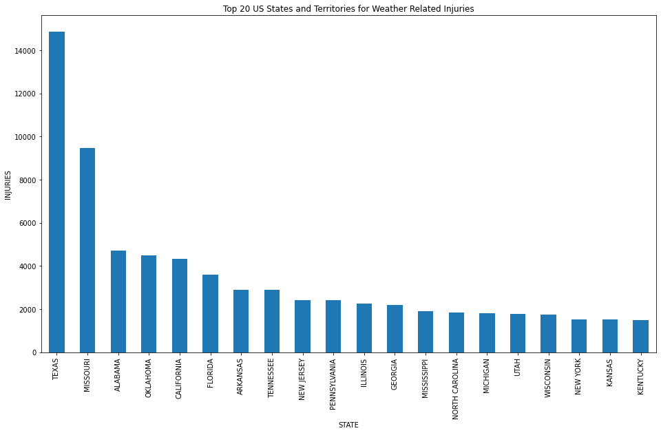

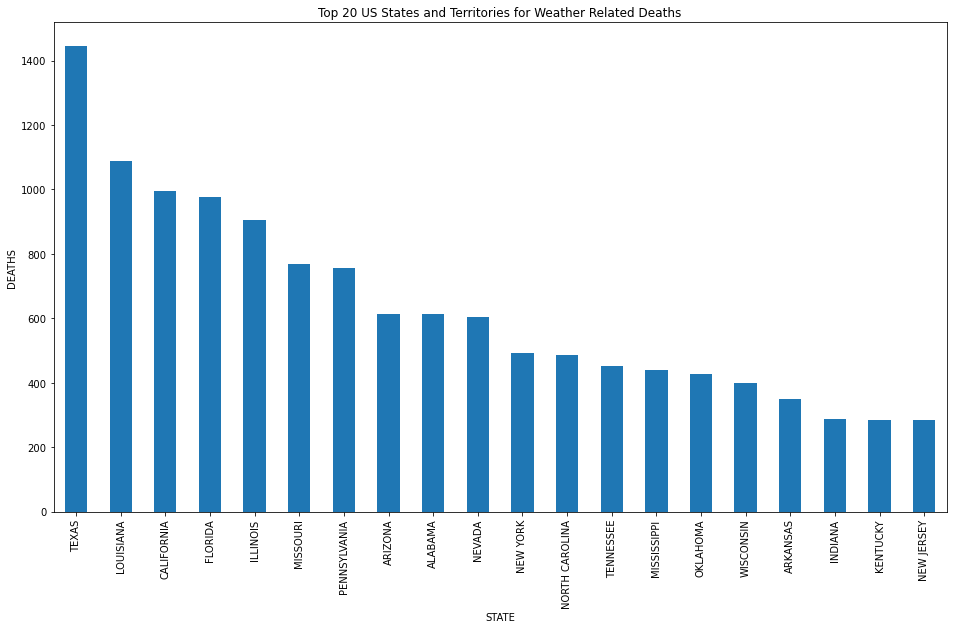

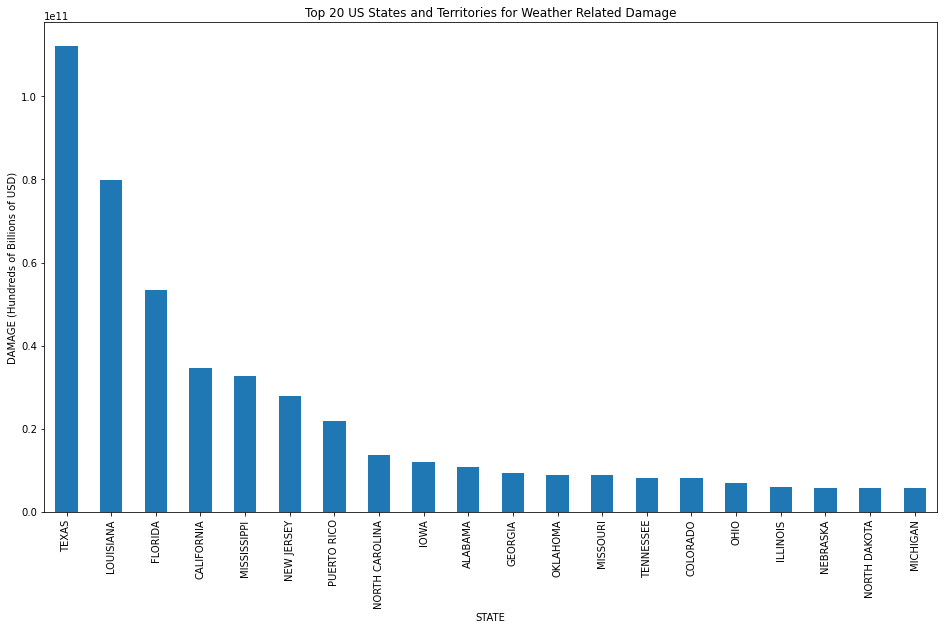

```python
# total injuries per state bar graph
plt.figure(figsize=(16,9))
(sums['INJURIES_DIRECT'] + sums['INJURIES_INDIRECT']).sort_values(ascending=False)[:20].plot(kind='bar')
plt.title('Top 20 US States and Territories for Weather Related Injuries')
plt.ylabel('INJURIES')
plt.show()

# total deaths per state bar graph
plt.figure(figsize=(16,9))
(sums['DEATHS_DIRECT'] + sums['DEATHS_INDIRECT']).sort_values(ascending=False)[:20].plot(kind='bar')
plt.title('Top 20 US States and Territories for Weather Related Deaths')
plt.ylabel('DEATHS')
plt.show()

# total damage per state bar graph
plt.figure(figsize=(16,9))
(sums['DAMAGE_PROPERTY'] + sums['DAMAGE_CROPS']).sort_values(ascending=False)[:20].plot(kind='bar')
plt.title('Top 20 US States and Territories for Weather Related Damage')
plt.ylabel('DAMAGE (Hundreds of Billions of USD)')
plt.show()
```

In the above two blocks of code, we first group all data by the state in which the weather phenomenon occurred and summed everything, giving us the total injuries, deaths and damage over the past 25 years for all US states. Afterwards, just to see which states are having the most trouble, I generated bar graphs for every state over the past 25 years. Of course, plotting sums could be misleading - consider that some states are much larger and therefore account for more damage even though nearby states experienced similar damage while being smaller. Also consider that some states may not have as much infrastructure that can be damaged. Nonetheless, this is a nice preliminary view of the state of weather in the US.

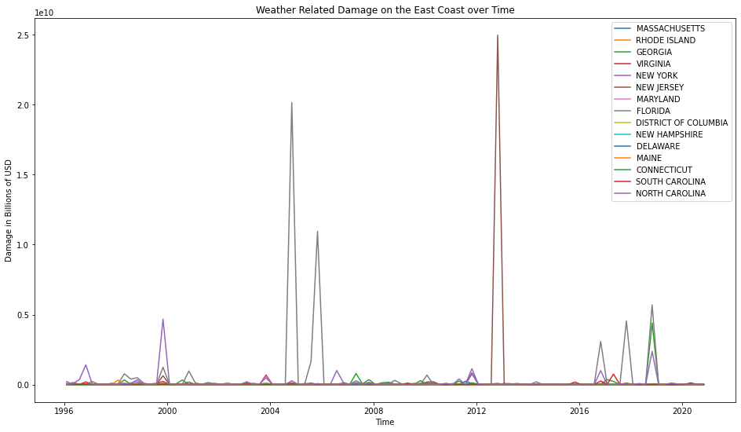

```python
plt.figure(figsize=(16,9))

for state in east_coast:
#     if state in ['FLORIDA', 'GEORGIA', 'NEW JERSEY', 'NORTH CAROLINA']:
#       continue

    temp = ec_df[ec_df['STATE'] == state]
    temp = temp.resample('3M', on='BEGIN_DATE_TIME').sum()

    plt.plot(temp.index, temp['DAMAGE_PROPERTY'] + temp['DAMAGE_CROPS'],label=state)
    plt.legend()

# plt.ylim(0,2*10**9)
plt.ylabel('Damage in Billions of USD')
plt.xlabel('Time')
plt.title('Weather Related Damage on the East Coast over Time')
plt.show()
plt.close()
```

In the code above, I first cycle through each state on the east coast and filter out their data. After resampling the data to season (3 month) sums, I plotted each state on the same axis. Unfortunately, some *huge* outliers, like Hurricane Sandy in New Jersey, for instance, drown out some of the relatively smaller nuances. If you run the above cell again with all the code uncommented, you'll notice that four states that include these huge spikes are ignored and therefore we get a better picture of how weather has wreaked havoc on the East Coast.

Below, I'll do something similar, but instead I will ignore days where more than $10M dollars of damage has occurred in a state. This is a relatively arbitrary filter, but should ignore the most extreme storms. Note that here you could also normalize values by dividing by square acreage or population to get more normalized sense of damage. I leave that as an exercise for the reader.

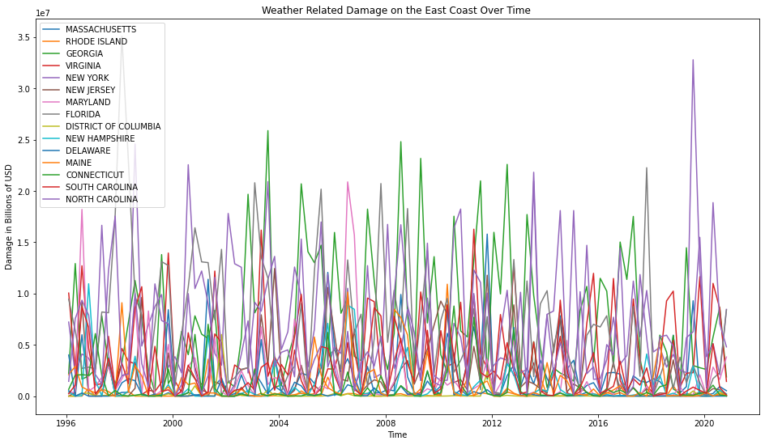

```python
plt.figure(figsize=(16,9))

# to select specific states, change east_coast to select specific states you are interested in!

for state in east_coast:

    temp = ec_df[ec_df['STATE'] == state]
    temp = temp.resample('D', on='BEGIN_DATE_TIME').sum() # sample by day

    # only keep rows where total damage is less than 10 mil
    temp = temp[(temp['DAMAGE_PROPERTY'] + temp['DAMAGE_CROPS']) < 10**7]

    temp = temp.resample('3M').sum() # resample by season after removing catastrophic storms

    plt.plot(temp.index, temp['DAMAGE_PROPERTY'] + temp['DAMAGE_CROPS'],label=state)
    plt.legend()

plt.ylabel('Damage in Billions of USD')
plt.xlabel('Time')
plt.title('Weather Related Damage on the East Coast Over Time ')
plt.show()
plt.close()
```

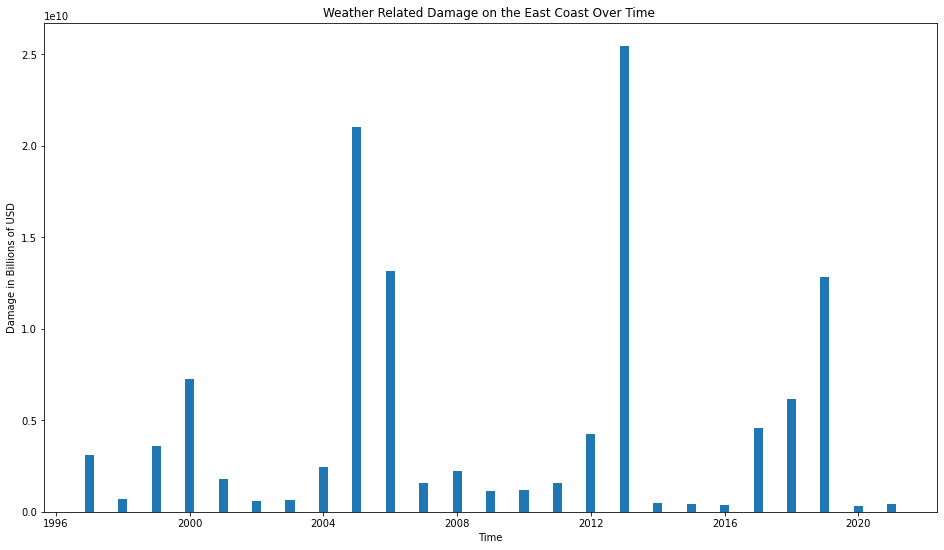

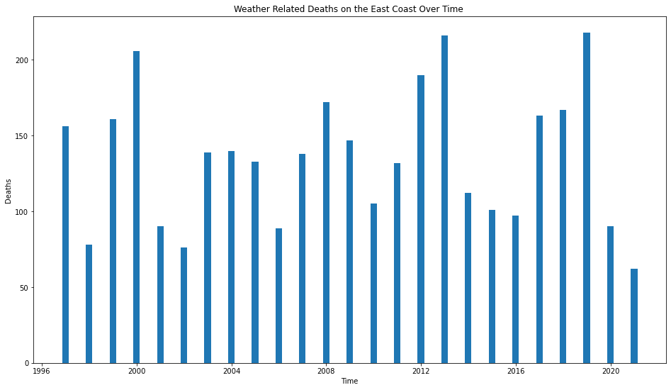

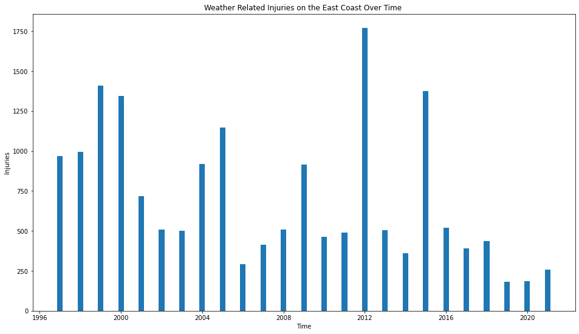

```python
temp = ec_df.resample('Y', on='BEGIN_DATE_TIME').sum()

plt.figure(figsize=(16,9))
plt.bar(temp.index, temp['DAMAGE_PROPERTY'] + temp['DAMAGE_CROPS'], width=100)

plt.ylabel('Damage in Billions of USD')
plt.xlabel('Time')
plt.title('Weather Related Damage on the East Coast Over Time ')
plt.show()
plt.close()

plt.figure(figsize=(16,9))
plt.bar(temp.index, temp['DEATHS_DIRECT'] + temp['DEATHS_INDIRECT'], width=100)

plt.ylabel('Deaths')
plt.xlabel('Time')
plt.title('Weather Related Deaths on the East Coast Over Time ')
plt.show()
plt.close()

plt.figure(figsize=(16,9))
plt.bar(temp.index, temp['INJURIES_DIRECT'] + temp['INJURIES_INDIRECT'], width=100)

plt.ylabel('Injuries')
plt.xlabel('Time')
plt.title('Weather Related Injuries on the East Coast Over Time ')
plt.show()
plt.close()
```

Let's address the following question now: are dangerous storms becoming more frequent? We will do this by thresholding days with extreme damages and counting the frequency.

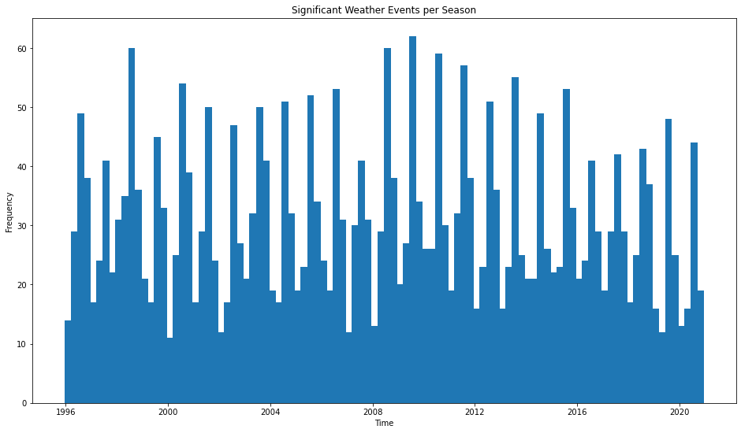

```python
temp = ec_df.resample('D', on='BEGIN_DATE_TIME').sum()
temp = temp[(temp['DAMAGE_PROPERTY'] + temp['DAMAGE_CROPS']) > 10**5]

temp = temp.resample('3M').count()

plt.figure(figsize=(16,9))

plt.bar(temp.index, temp['DAMAGE_PROPERTY'], width=100)

plt.ylabel('Frequency')
plt.xlabel('Time')
plt.title('Significant Weather Events per Season')
plt.show()
plt.close()
```

This echoes the same narrative as earlier - something that appears to be relatively periodic. Unfortunately, we don't have enough data from this database to indicate exactly whether there is a positive trend within this periodic nature. As with anything in the real world, there is many more factors than just time, so we should keep that in mind when evaluating! Anyways, for our last kind of exploratory analysis, let's split up these weather phenomenon into subsets and see exactly how each type of weather phenomenon affects the East Coast.

```python
print(ec_df['EVENT_TYPE'].unique())

winter = ['Heavy Snow', 'Winter Storm','Cold/Wind Chill','Hail', 'Winter Weather','Blizzard', 'Avalanche',\
          'Ice Storm', 'Frost/Freeze','Sleet', 'Lake-Effect Snow','Freezing Fog', 'Extreme Cold/Wind Chill',]

storms = ['Thunderstorm Wind','Lightning','Heavy Rain','Tropical Storm','Hurricane (Typhoon)','Storm Surge/Tide',\
         'Tropical Depression', 'Hurricane',]

winds = ['High Wind','Strong Wind',]

other = ['Flood','Flash Flood','Dense Fog', 'Tornado', 'Coastal Flood', 'Heat', 'Wildfire','Waterspout', \
         'Rip Current', 'Funnel Cloud','Debris Flow', 'Drought','Dust Devil', 'High Surf','Astronomical Low Tide',\
        'Excessive Heat','Dust Storm', 'Seiche','Lakeshore Flood', 'Dense Smoke', 'Landslide','Tsunami']
```

```
['Heavy Snow' 'Winter Storm' 'Flood' 'High Wind' 'Flash Flood'
 'Cold/Wind Chill' 'Thunderstorm Wind' 'Hail' 'Winter Weather' 'Blizzard'
 'Avalanche' 'Ice Storm' 'Frost/Freeze' 'Lightning' 'Dense Fog' 'Tornado'
 'Coastal Flood' 'Heat' 'Wildfire' 'Heavy Rain' 'Waterspout' 'Rip Current'
 'Funnel Cloud' 'Tropical Storm' 'Debris Flow' 'Drought'
 'Hurricane (Typhoon)' 'Strong Wind' 'Dust Devil' 'High Surf'
 'Storm Surge/Tide' 'Sleet' 'Lake-Effect Snow' 'Astronomical Low Tide'
 'Freezing Fog' 'Extreme Cold/Wind Chill' 'Excessive Heat' 'Dust Storm'
 'Seiche' 'Tropical Depression' 'Hurricane' 'Lakeshore Flood'
 'Dense Smoke' 'Landslide' 'Tsunami']
```

Above I just manually seperated all the different event types into seperate bins. We'll use these arrays to create some more graphs, first depicting the spread across the east coast, and then at a more fine tuned level.

```python
temp = ec_df.copy() # create copy of dataframe

# group certain event types in our dataframe
temp.loc[temp['EVENT_TYPE'].isin(winter),'EVENT_TYPE'] = 'winter'
temp.loc[temp['EVENT_TYPE'].isin(storms),'EVENT_TYPE'] = 'storms'
temp.loc[temp['EVENT_TYPE'].isin(winds),'EVENT_TYPE'] = 'winds'
temp.loc[temp['EVENT_TYPE'].isin(other),'EVENT_TYPE'] = 'other'

# show df
temp.head()
```

|  | STATE | EVENT_TYPE | BEGIN_DATE_TIME | INJURIES_DIRECT | INJURIES_INDIRECT | DEATHS_DIRECT | DEATHS_INDIRECT | DAMAGE_PROPERTY | DAMAGE_CROPS | MAGNITUDE | MAGNITUDE_TYPE | FLOOD_CAUSE | EPISODE_NARRATIVE | EVENT_NARRATIVE |
| --- | --- | --- | --- | --- | --- | --- | --- | --- | --- | --- | --- | --- | --- | --- |
| 15 | MASSACHUSETTS | winter | 1996-01-02 21:00:00 | 0 | 0 | 0 | 0 | 0.0 | 0.0 | NaN | NaN | NaN | A strong low pressure system moved from Tennes... | NaN |
| 17 | RHODE ISLAND | winter | 1996-01-02 21:00:00 | 0 | 0 | 0 | 0 | 0.0 | 0.0 | NaN | NaN | NaN | A strong low pressure system moved from Tennes... | NaN |
| 21 | RHODE ISLAND | winter | 1996-01-07 17:00:00 | 0 | 0 | 0 | 0 | 0.0 | 0.0 | NaN | NaN | NaN | An intense east coast low pressure system move... | NaN |
| 29 | GEORGIA | winter | 1996-02-02 10:00:00 | 0 | 0 | 0 | 0 | 20000.0 | 0.0 | NaN | NaN | NaN | Freezing rain accumulated 1 to 2 inches before... | NaN |
| 30 | VIRGINIA | winter | 1996-01-12 01:00:00 | 0 | 0 | 0 | 0 | 0.0 | 0.0 | NaN | NaN | NaN | The second storm in less than a week dumped lo... | NaN |

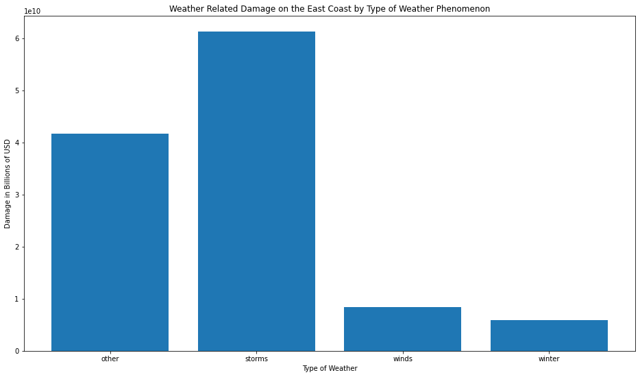

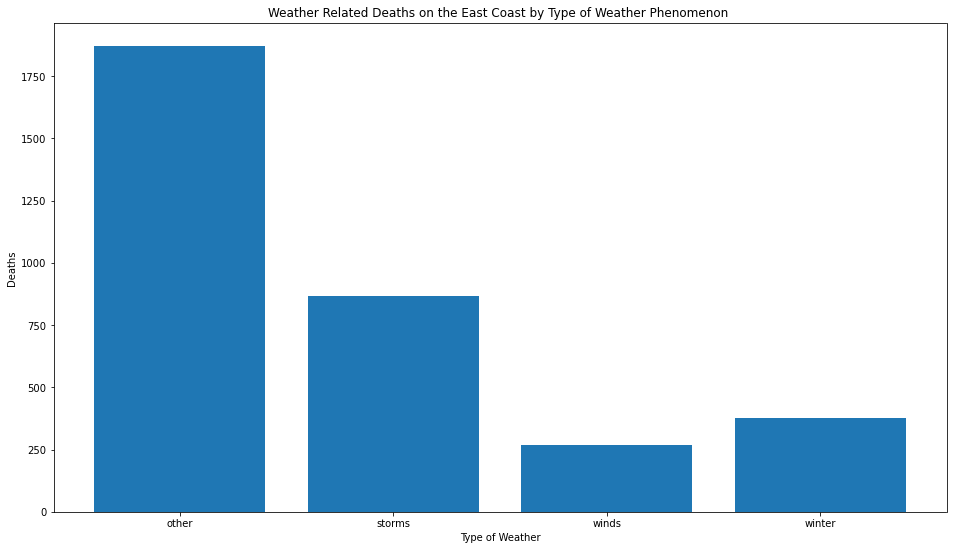

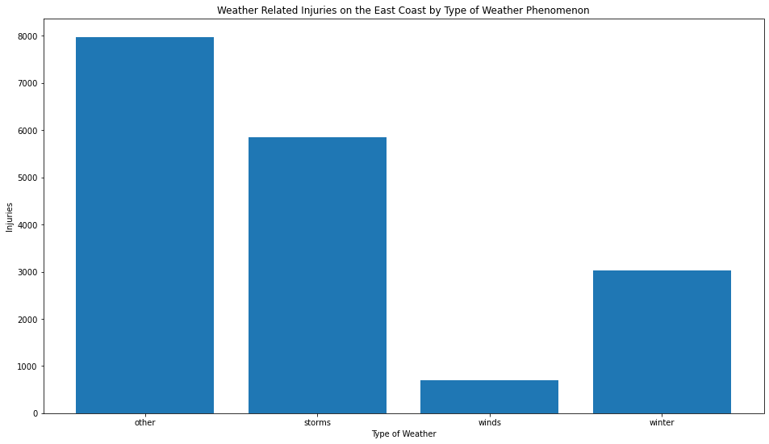

```python
eastcoast_grouped = temp.groupby('EVENT_TYPE').sum()

plt.figure(figsize=(16,9))
plt.bar(eastcoast_grouped.index, eastcoast_grouped['DAMAGE_PROPERTY'] + eastcoast_grouped['DAMAGE_CROPS'])

plt.ylabel('Damage in Billions of USD')
plt.xlabel('Type of Weather')
plt.title('Weather Related Damage on the East Coast by Type of Weather Phenomenon')
plt.show()
plt.close()

plt.figure(figsize=(16,9))
plt.bar(eastcoast_grouped.index, eastcoast_grouped['DEATHS_DIRECT'] + eastcoast_grouped['DEATHS_INDIRECT'])

plt.ylabel('Deaths')
plt.xlabel('Type of Weather')
plt.title('Weather Related Deaths on the East Coast by Type of Weather Phenomenon ')
plt.show()
plt.close()

plt.figure(figsize=(16,9))
plt.bar(eastcoast_grouped.index, eastcoast_grouped['INJURIES_DIRECT'] + eastcoast_grouped['INJURIES_INDIRECT'])

plt.ylabel('Injuries')
plt.xlabel('Type of Weather')
plt.title('Weather Related Injuries on the East Coast by Type of Weather Phenomenon')
plt.show()
plt.close()
```

I implore you to do some further exploration, perhaps splitting up and looking into what types of "other" weather events contribute to so many deaths and injuries on the East Coast - I suspect extreme heat may be a culprit. Lastly, let's observe how each category changes over time. Since I am from New Jersey, I'm going to highlight it, but you can always change the code to produce graphs for any of the states or make a loop that makes graphs for every state. I decided against the loop since producing so many graphs would be somewhat meaningless.

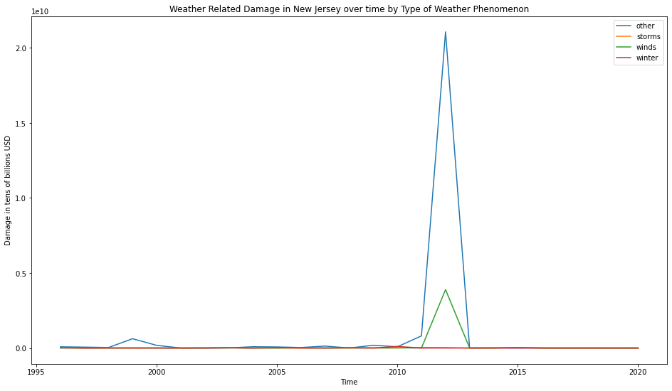

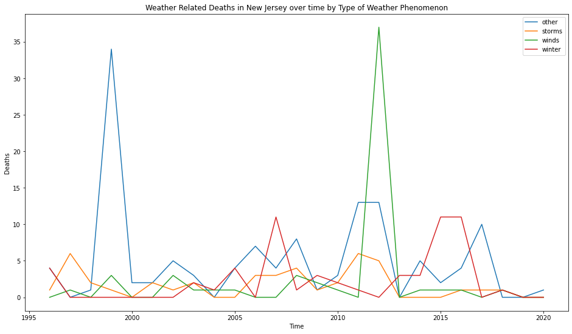

[figure not shown]

```python
# for state in eastcoastL
grouped_temp = temp[temp['STATE'] == 'NEW JERSEY'].groupby([temp['BEGIN_DATE_TIME'].dt.year, 'EVENT_TYPE']).sum()

# damage plot
plt.figure(figsize=(16,9))
for eventtype in grouped_temp.index.get_level_values(1).unique():
    grouped_temp2 = grouped_temp[grouped_temp.index.get_level_values(1) == eventtype]
    plt.plot(grouped_temp2.index.get_level_values(0),grouped_temp2['DAMAGE_PROPERTY'] + grouped_temp2['DAMAGE_CROPS'],label=eventtype)
    plt.legend()

plt.title('Weather Related Damage in New Jersey over time by Type of Weather Phenomenon')
plt.xlabel('Time')
plt.ylabel('Damage in tens of billions USD')
plt.show()

# deaths plot
plt.figure(figsize=(16,9))
for eventtype in grouped_temp.index.get_level_values(1).unique():
    grouped_temp2 = grouped_temp[grouped_temp.index.get_level_values(1) == eventtype]
    plt.plot(grouped_temp2.index.get_level_values(0),grouped_temp2['DEATHS_DIRECT'] + grouped_temp2['DEATHS_INDIRECT'],label=eventtype)
    plt.legend()

plt.title('Weather Related Deaths in New Jersey over time by Type of Weather Phenomenon')
plt.xlabel('Time')
plt.ylabel('Deaths')
plt.show()

# injuries plot
plt.figure(figsize=(16,9))
for eventtype in grouped_temp.index.get_level_values(1).unique():
    grouped_temp2 = grouped_temp[grouped_temp.index.get_level_values(1) == eventtype]
    plt.plot(grouped_temp2.index.get_level_values(0),grouped_temp2['DEATHS_DIRECT'] + grouped_temp2['DEATHS_INDIRECT'],label=eventtype)
    plt.legend()

plt.title('Weather Related Injuries in New Jersey over time by Type of Weather Phenomenon')
plt.xlabel('Time')
plt.ylabel('Injuries')
plt.show()

# plt.plot(grouped_temp.index.get_level_values(0),grouped_temp['DEATHS_DIRECT'] + grouped_temp['DEATHS_INDIRECT'],label=grouped_temp.index.get_level_values(1))
```

Consequences of Hurricane Sandy and Hurricane Floyd seem to dominate these graphs. Now that we have done a great deep dive into what all the data looks like, lets try and make some predictions.

# Model Construction and Analysis

In this section of the tutorial, we will try to build a predictor for frequency of extreme weather events using timeseries analysis.

### Choosing a Model: Facebook Prophet

The aim of this model is to closely predict when there will be a frequent number of severe storms in an area. So, since this frequency appeared to be relatively periodic, we can see how some timeseries analysis would work against the data. To perform this analysis, I decided to use the Prophet function from Facebook. You can read more about it [here](https://facebook.github.io/prophet/docs/quick_start.html#python-api).

Prophet, like all time-series analysis tools, use a variety of fine-tuned parameters to predict how something changes over time. For instance, time-series analysis performs very well when predicting shopping patterns, which exhibits a very periodic pattern; people like to shop on weekends when they have free time.

FBProphet relies on three main metrics: trend, seasonality, and decay/growth. Trend relates to how the data generally trend. Consider the function $f(x) = x + \sin(x)$. If you graph it, you notice that there is a trend exhibited by the $x$ term. Seasonality refers to the other aspect of $f$, the $\sin(x)$ portion. Holt-Winters aims to match the periodic nature using this seasonality term. Lastly is decay/growth, which relates to a second derivate of the sequence: are we increasing/decreasing more and more over time? Fitting these three metrics on training data, it should be able to predict future values assuming a periodic nature accurately.

Below we install the package for fbprohet. Just as a refresher, below is the code we used to find the number of significant weather events per season accross the east coast:

```python
!pip install fbprophet
```

[output not shown]

[output cut: 10 more lines]

[output not shown]

```
Importing plotly failed. Interactive plots will not work.
```

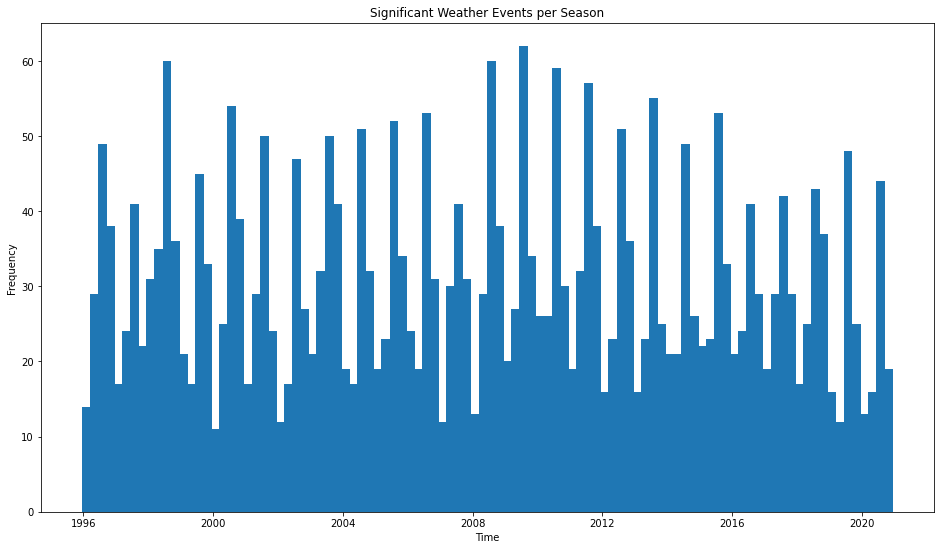

```python
from fbprophet import Prophet # will need this later

temp = ec_df.resample('D', on='BEGIN_DATE_TIME').sum()
temp = temp[(temp['DAMAGE_PROPERTY'] + temp['DAMAGE_CROPS']) > 10**5]

temp = temp.resample('3M').count()

plt.figure(figsize=(16,9))

plt.bar(temp.index, temp['DAMAGE_PROPERTY'], width=100)

plt.ylabel('Frequency')
plt.xlabel('Time')
plt.title('Significant Weather Events per Season')
plt.show()
plt.close()
```

```python
result_df = temp[['DAMAGE_PROPERTY']]
result_df['ds'] = result_df.index
result_df['y'] = result_df[['DAMAGE_PROPERTY']]
result_df.head()
```

| BEGIN_DATE_TIME | DAMAGE_PROPERTY | ds | y |
| --- | --- | --- | --- |
| 1996-01-31 | 14 | 1996-01-31 | 14 |
| 1996-04-30 | 29 | 1996-04-30 | 29 |
| 1996-07-31 | 49 | 1996-07-31 | 49 |
| 1996-10-31 | 38 | 1996-10-31 | 38 |
| 1997-01-31 | 17 | 1997-01-31 | 17 |

```python
m = Prophet(weekly_seasonality=False, daily_seasonality=False)
m.add_seasonality(name='decade', period=3650, fourier_order=15)
m.fit(result_df)

future = m.make_future_dataframe(periods=15, freq='3M')
future.tail()

forecast = m.predict(future)

forecast.tail()
```

|  | ds | trend | yhat_lower | yhat_upper | trend_lower | trend_upper | additive_terms | additive_terms_lower | additive_terms_upper | decade | decade_lower | decade_upper | yearly | yearly_lower | yearly_upper | multiplicative_terms | multiplicative_terms_lower | multiplicative_terms_upper | yhat |
| --- | --- | --- | --- | --- | --- | --- | --- | --- | --- | --- | --- | --- | --- | --- | --- | --- | --- | --- | --- |
| 110 | 2023-07-31 | 13.306293 | 40.410371 | 50.740579 | 13.179520 | 13.423263 | 32.129332 | 32.129332 | 32.129332 | 4.373920 | 4.373920 | 4.373920 | 27.755412 | 27.755412 | 27.755412 | 0.0 | 0.0 | 0.0 | 45.435625 |
| 111 | 2023-10-31 | 13.148122 | 21.436795 | 31.644968 | 13.000877 | 13.281173 | 13.663447 | 13.663447 | 13.663447 | 1.007997 | 1.007997 | 1.007997 | 12.655450 | 12.655450 | 12.655450 | 0.0 | 0.0 | 0.0 | 26.811569 |
| 112 | 2024-01-31 | 12.989952 | 6.359197 | 16.484702 | 12.820204 | 13.145593 | -1.632358 | -1.632358 | -1.632358 | -2.518642 | -2.518642 | -2.518642 | 0.886284 | 0.886284 | 0.886284 | 0.0 | 0.0 | 0.0 | 11.357593 |
| 113 | 2024-04-30 | 12.835219 | 8.526003 | 18.932304 | 12.645642 | 13.010277 | 1.021519 | 1.021519 | 1.021519 | -3.488080 | -3.488080 | -3.488080 | 4.509598 | 4.509598 | 4.509598 | 0.0 | 0.0 | 0.0 | 13.856738 |
| 114 | 2024-07-31 | 12.677049 | 35.495741 | 45.890952 | 12.463483 | 12.875495 | 28.374638 | 28.374638 | 28.374638 | 0.246282 | 0.246282 | 0.246282 | 28.128355 | 28.128355 | 28.128355 | 0.0 | 0.0 | 0.0 | 41.051687 |

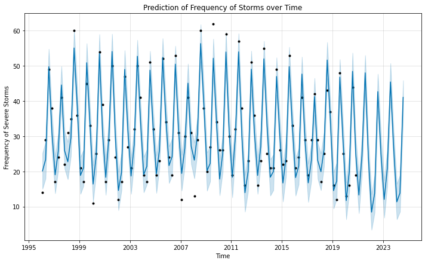

```python
m.plot(forecast)
plt.ylabel('Frequency of Severe Storms')
plt.xlabel('Time')
plt.title('Prediction of Frequency of Storms over Time')
plt.show()
```

Above we have our fitted model in blue, with uncertainty in light blue. The black dots are our actual data points. Note that Facebook prophet generates a model that will best fit for our data on its own! It is a very easy to use software for anyone looking to do any kind of time series analysis. I think its interesting that it appears frequency of these storms are trending down, but this might have to do with some of the disadvantages of this method.

# Conclusion

Now that we have walked through all the steps of the data science process, we should end by discussing any insights we may have found and the implication of these insights.

As mentioned in the previous paragraph, there is plenty of future analysis that can be done by branching off the findings we have here. To learn more about data science, I recommend looking at [Medium](https://medium.com/topic/machine-learning)!.